# Project3EnsembleTech_1007Ankush

### Problem statement (Term Deposit Sale)

**Goal**

Using the data collected from existing customers, build a model that will help the marketing team identify potential customers who are relatively more likely to subscribe term deposit and thus increase their hit ratio.

**Resources Available** The historical data for this project is available in file  
https://archive.ics.uci.edu/ml/datasets/Bank+Marketing

**Attribute information**

**Input variables:**

Bank client data:

- 1. age: Continuous feature
- 1. job: Type of job (management, technician, entrepreneur, blue-collar, etc.)
- 1. marital: marital status (married, single, divorced)
- 1. education: education level (primary, secondary, tertiary)
- 1. default: has credit in default?
- 1. housing: has housing loan?
- 1. loan: has personal loan?
- 1. balance in account

Related to previous contact:

- 1. contact: contact communication type
- 1. month: last contact month of year
- 1. day: last contact day of the month
- 1. duration: last contact duration, in seconds*

Other attributes:

- 1. campaign: number of contacts performed during this campaign and for this client
- 1. pdays: number of days that passed by after the client was last contacted from a previous campaign (-1 tells us the person has not been contacted or contact period is beyond 900 days)
- 1. previous: number of times the client has been contacted before for the last campaign to subscribe term deposit
- 1. poutcome: outcome of the previous marketing campaign

Output variable (desired target):

- 1. Target: Tell us has the client subscribed a term deposit. (Yes, No)

```python
import numpy as np
import pandas as pd
import matplotlib.pyplot as plt
%matplotlib inline
import seaborn as sns

from sklearn.model_selection import train_test_split
from sklearn.linear_model import LinearRegression
import warnings
warnings.filterwarnings('ignore')
from sklearn.metrics import confusion_matrix, recall_score, precision_score, f1_score, roc_auc_score,accuracy_score

# Load the data into pandas dataframe
bData = pd.read_csv('bank-full.csv')

#Print Data type
print(bData.dtypes)

#Print Shape
print('\n\n***Shape of dataset ')
print(bData.shape)

#Are there any nulls
print('\n\n***Check for null values in given dataset is : '+str(bData.isnull().values.any()))


#Print Statistical Summary
print('\n\n***Statistical Summary \n ')
bData.describe().T
```

```
age           int64
job          object
marital      object
education    object
default      object
balance       int64
housing      object
loan         object
contact      object
day           int64
month        object
duration      int64
campaign      int64
pdays         int64
previous      int64
poutcome     object
Target       object
dtype: object


***Shape of dataset
(45211, 17)


***Check for null values in given dataset is : False


***Statistical Summary
```

|  | count | mean | std | min | 25% | 50% | 75% | max |
| --- | --- | --- | --- | --- | --- | --- | --- | --- |
| age | 45211.0 | 40.936210 | 10.618762 | 18.0 | 33.0 | 39.0 | 48.0 | 95.0 |
| balance | 45211.0 | 1362.272058 | 3044.765829 | -8019.0 | 72.0 | 448.0 | 1428.0 | 102127.0 |
| day | 45211.0 | 15.806419 | 8.322476 | 1.0 | 8.0 | 16.0 | 21.0 | 31.0 |
| duration | 45211.0 | 258.163080 | 257.527812 | 0.0 | 103.0 | 180.0 | 319.0 | 4918.0 |
| campaign | 45211.0 | 2.763841 | 3.098021 | 1.0 | 1.0 | 2.0 | 3.0 | 63.0 |
| pdays | 45211.0 | 40.197828 | 100.128746 | -1.0 | -1.0 | -1.0 | -1.0 | 871.0 |
| previous | 45211.0 | 0.580323 | 2.303441 | 0.0 | 0.0 | 0.0 | 0.0 | 275.0 |

```python
print(bData[bData['balance'] <0]['balance'].count())
```

```
3766
```

**Observation**

- balance for 3766 rows has negative value : Need business insights whether this is possible for Term deposit , leaving this data AS IS.

```python
bData.head()
```

|  | age | job | marital | education | default | balance | housing | loan | contact | day | month | duration | campaign | pdays | previous | poutcome | Target |
| --- | --- | --- | --- | --- | --- | --- | --- | --- | --- | --- | --- | --- | --- | --- | --- | --- | --- |
| 0 | 58 | management | married | tertiary | no | 2143 | yes | no | unknown | 5 | may | 261 | 1 | -1 | 0 | unknown | no |
| 1 | 44 | technician | single | secondary | no | 29 | yes | no | unknown | 5 | may | 151 | 1 | -1 | 0 | unknown | no |
| 2 | 33 | entrepreneur | married | secondary | no | 2 | yes | yes | unknown | 5 | may | 76 | 1 | -1 | 0 | unknown | no |
| 3 | 47 | blue-collar | married | unknown | no | 1506 | yes | no | unknown | 5 | may | 92 | 1 | -1 | 0 | unknown | no |
| 4 | 33 | unknown | single | unknown | no | 1 | no | no | unknown | 5 | may | 198 | 1 | -1 | 0 | unknown | no |

```python
bData.info()
```

```
<class 'pandas.core.frame.DataFrame'>
RangeIndex: 45211 entries, 0 to 45210
Data columns (total 17 columns):
 #   Column     Non-Null Count  Dtype
---  ------     --------------  -----
 0   age        45211 non-null  int64
 1   job        45211 non-null  object
 2   marital    45211 non-null  object
 3   education  45211 non-null  object
 4   default    45211 non-null  object
 5   balance    45211 non-null  int64
 6   housing    45211 non-null  object
 7   loan       45211 non-null  object
 8   contact    45211 non-null  object
 9   day        45211 non-null  int64
 10  month      45211 non-null  object
 11  duration   45211 non-null  int64
 12  campaign   45211 non-null  int64
 13  pdays      45211 non-null  int64
 14  previous   45211 non-null  int64
 15  poutcome   45211 non-null  object
 16  Target     45211 non-null  object
dtypes: int64(7), object(10)
memory usage: 5.9+ MB
```

**PreProcessingTag0**

**Think to consider:** `Convert all object data type to category`

```python
#Need to convert object data type to category
for feature in bData.columns:
    if bData[feature].dtype == 'object':
        bData[feature] = pd.Categorical(bData[feature])
bData.head(10)
```

|  | age | job | marital | education | default | balance | housing | loan | contact | day | month | duration | campaign | pdays | previous | poutcome | Target |
| --- | --- | --- | --- | --- | --- | --- | --- | --- | --- | --- | --- | --- | --- | --- | --- | --- | --- |
| 0 | 58 | management | married | tertiary | no | 2143 | yes | no | unknown | 5 | may | 261 | 1 | -1 | 0 | unknown | no |
| 1 | 44 | technician | single | secondary | no | 29 | yes | no | unknown | 5 | may | 151 | 1 | -1 | 0 | unknown | no |
| 2 | 33 | entrepreneur | married | secondary | no | 2 | yes | yes | unknown | 5 | may | 76 | 1 | -1 | 0 | unknown | no |
| 3 | 47 | blue-collar | married | unknown | no | 1506 | yes | no | unknown | 5 | may | 92 | 1 | -1 | 0 | unknown | no |
| 4 | 33 | unknown | single | unknown | no | 1 | no | no | unknown | 5 | may | 198 | 1 | -1 | 0 | unknown | no |
| 5 | 35 | management | married | tertiary | no | 231 | yes | no | unknown | 5 | may | 139 | 1 | -1 | 0 | unknown | no |
| 6 | 28 | management | single | tertiary | no | 447 | yes | yes | unknown | 5 | may | 217 | 1 | -1 | 0 | unknown | no |
| 7 | 42 | entrepreneur | divorced | tertiary | yes | 2 | yes | no | unknown | 5 | may | 380 | 1 | -1 | 0 | unknown | no |
| 8 | 58 | retired | married | primary | no | 121 | yes | no | unknown | 5 | may | 50 | 1 | -1 | 0 | unknown | no |
| 9 | 43 | technician | single | secondary | no | 593 | yes | no | unknown | 5 | may | 55 | 1 | -1 | 0 | unknown | no |

```python
bData.columns
```

```
Index(['age', 'job', 'marital', 'education', 'default', 'balance', 'housing',
       'loan', 'contact', 'day', 'month', 'duration', 'campaign', 'pdays',
       'previous', 'poutcome', 'Target'],
      dtype='object')
```

## Univariate Analysis

```python
#Value counts of all categorical columns.
# print(bData.columns)
catCols = {'job', 'marital', 'education', 'default', 'housing','loan', 'contact', 'month','poutcome', 'Target'}

for i in list(catCols):
    print(bData[i].value_counts())
    print()
```

```
cellular     29285
unknown      13020
telephone     2906
Name: contact, dtype: int64

secondary    23202
tertiary     13301
primary       6851
unknown       1857
Name: education, dtype: int64

no     37967
yes     7244
Name: loan, dtype: int64

yes    25130
no     20081
Name: housing, dtype: int64

may    13766
jul     6895
aug     6247
jun     5341
nov     3970
apr     2932
feb     2649
jan     1403
oct      738
sep      579
mar      477
dec      214
Name: month, dtype: int64

unknown    36959
failure     4901
other       1840
success     1511
Name: poutcome, dtype: int64

blue-collar      9732
```

[output cut: 10 more lines]

```
unknown           288
Name: job, dtype: int64

no     44396
yes      815
Name: default, dtype: int64

no     39922
yes     5289
Name: Target, dtype: int64

married     27214
single      12790
divorced     5207
Name: marital, dtype: int64
```

**Following columns need further review for "unknown"**

**Univariate and Bivariate analysis will give more details**

```python
#Convert categorical values to numeric
replaceStruct = {
                "job": {"blue-collar": 1, "management": 2 ,"technician": 3 ,"admin.": 4, "services":5,"retired":6, "self-employed":7,"entrepreneur":8,"unemployed":9,"housemaid":10,"student":11,"unknown":-1},
                "marital": {"married": 1, "divorced":2 , "single": 3},
                "education": {"primary": 1, "secondary":2 , "tertiary": 3,"unknown": -1},
                "default": {"no": 1, "yes": 2 },
                "housing": {"no": 1, "yes": 2 },
                "contact":  {"cellular": 1, "telephone": 2, "unknown": -1 },
                "loan":    {"no": 1, "yes": 2 },
                "month":   {"jan": 1, "feb": 2 ,"mar": 3 ,"apr": 4, "may":5,"jun":6, "jul":7,"aug":8,"sep":9,"oct":10,"nov":11,"dec":12},
                "poutcome": {"failure": 1, "other": 2,"success":3,"unknown": -1 },
                "Target":     {"no": 0, "yes": 1 }
                }
```

**Assumption**

- No one-hot-encoding used, assumption is, it gives better results in decision tree like methods.

```python
bData=bData.replace(replaceStruct)
bData.head(10)
```

|  | age | job | marital | education | default | balance | housing | loan | contact | day | month | duration | campaign | pdays | previous | poutcome | Target |
| --- | --- | --- | --- | --- | --- | --- | --- | --- | --- | --- | --- | --- | --- | --- | --- | --- | --- |
| 0 | 58 | 2 | 1 | 3 | 1 | 2143 | 2 | 1 | -1 | 5 | 5 | 261 | 1 | -1 | 0 | -1 | 0 |
| 1 | 44 | 3 | 3 | 2 | 1 | 29 | 2 | 1 | -1 | 5 | 5 | 151 | 1 | -1 | 0 | -1 | 0 |
| 2 | 33 | 8 | 1 | 2 | 1 | 2 | 2 | 2 | -1 | 5 | 5 | 76 | 1 | -1 | 0 | -1 | 0 |
| 3 | 47 | 1 | 1 | -1 | 1 | 1506 | 2 | 1 | -1 | 5 | 5 | 92 | 1 | -1 | 0 | -1 | 0 |
| 4 | 33 | -1 | 3 | -1 | 1 | 1 | 1 | 1 | -1 | 5 | 5 | 198 | 1 | -1 | 0 | -1 | 0 |
| 5 | 35 | 2 | 1 | 3 | 1 | 231 | 2 | 1 | -1 | 5 | 5 | 139 | 1 | -1 | 0 | -1 | 0 |
| 6 | 28 | 2 | 3 | 3 | 1 | 447 | 2 | 2 | -1 | 5 | 5 | 217 | 1 | -1 | 0 | -1 | 0 |
| 7 | 42 | 8 | 2 | 3 | 2 | 2 | 2 | 1 | -1 | 5 | 5 | 380 | 1 | -1 | 0 | -1 | 0 |
| 8 | 58 | 6 | 1 | 1 | 1 | 121 | 2 | 1 | -1 | 5 | 5 | 50 | 1 | -1 | 0 | -1 | 0 |
| 9 | 43 | 3 | 3 | 2 | 1 | 593 | 2 | 1 | -1 | 5 | 5 | 55 | 1 | -1 | 0 | -1 | 0 |

```python
bData.info()
```

```
<class 'pandas.core.frame.DataFrame'>
RangeIndex: 45211 entries, 0 to 45210
Data columns (total 17 columns):
 #   Column     Non-Null Count  Dtype
---  ------     --------------  -----
 0   age        45211 non-null  int64
 1   job        45211 non-null  int64
 2   marital    45211 non-null  int64
 3   education  45211 non-null  int64
 4   default    45211 non-null  int64
 5   balance    45211 non-null  int64
 6   housing    45211 non-null  int64
 7   loan       45211 non-null  int64
 8   contact    45211 non-null  int64
 9   day        45211 non-null  int64
 10  month      45211 non-null  int64
 11  duration   45211 non-null  int64
 12  campaign   45211 non-null  int64
 13  pdays      45211 non-null  int64
 14  previous   45211 non-null  int64
 15  poutcome   45211 non-null  int64
 16  Target     45211 non-null  int64
dtypes: int64(17)
memory usage: 5.9 MB
```

```python
#Print Statistical Summary
print('\n\n***Statistical Summary After replace\n ')
bData.describe().T
```

```
***Statistical Summary After replace
```

|  | count | mean | std | min | 25% | 50% | 75% | max |
| --- | --- | --- | --- | --- | --- | --- | --- | --- |
| age | 45211.0 | 40.936210 | 10.618762 | 18.0 | 33.0 | 39.0 | 48.0 | 95.0 |
| job | 45211.0 | 3.618212 | 2.610178 | -1.0 | 2.0 | 3.0 | 5.0 | 11.0 |
| marital | 45211.0 | 1.680963 | 0.884908 | 1.0 | 1.0 | 1.0 | 3.0 | 3.0 |
| education | 45211.0 | 2.019442 | 0.902795 | -1.0 | 2.0 | 2.0 | 3.0 | 3.0 |
| default | 45211.0 | 1.018027 | 0.133049 | 1.0 | 1.0 | 1.0 | 1.0 | 2.0 |
| balance | 45211.0 | 1362.272058 | 3044.765829 | -8019.0 | 72.0 | 448.0 | 1428.0 | 102127.0 |
| housing | 45211.0 | 1.555838 | 0.496878 | 1.0 | 1.0 | 2.0 | 2.0 | 2.0 |
| loan | 45211.0 | 1.160226 | 0.366820 | 1.0 | 1.0 | 1.0 | 1.0 | 2.0 |
| contact | 45211.0 | 0.488310 | 0.976936 | -1.0 | -1.0 | 1.0 | 1.0 | 2.0 |
| day | 45211.0 | 15.806419 | 8.322476 | 1.0 | 8.0 | 16.0 | 21.0 | 31.0 |
| month | 45211.0 | 6.144655 | 2.408034 | 1.0 | 5.0 | 6.0 | 8.0 | 12.0 |
| duration | 45211.0 | 258.163080 | 257.527812 | 0.0 | 103.0 | 180.0 | 319.0 | 4918.0 |
| campaign | 45211.0 | 2.763841 | 3.098021 | 1.0 | 1.0 | 2.0 | 3.0 | 63.0 |
| pdays | 45211.0 | 40.197828 | 100.128746 | -1.0 | -1.0 | -1.0 | -1.0 | 871.0 |
| previous | 45211.0 | 0.580323 | 2.303441 | 0.0 | 0.0 | 0.0 | 0.0 | 275.0 |
| poutcome | 45211.0 | -0.527416 | 1.054192 | -1.0 | -1.0 | -1.0 | -1.0 | 3.0 |
| Target | 45211.0 | 0.116985 | 0.321406 | 0.0 | 0.0 | 0.0 | 0.0 | 1.0 |

```python
#Get unique count
bData.nunique()
```

```
age            77
job            12
marital         3
education       4
default         2
balance      7168
housing         2
loan            2
contact         3
day            31
month          12
duration     1573
campaign       48
pdays         559
previous       41
poutcome        4
Target          2
dtype: int64
```

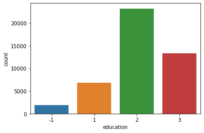

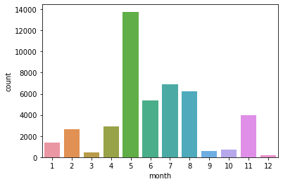

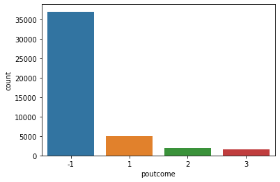

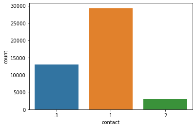

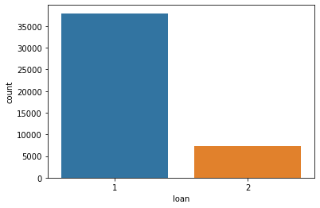

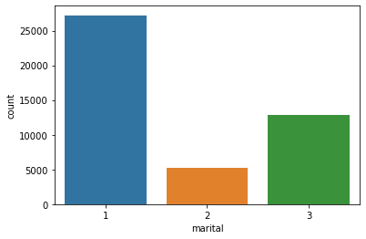

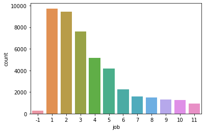

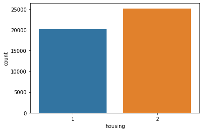

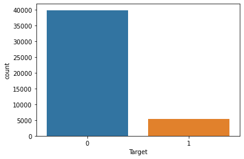

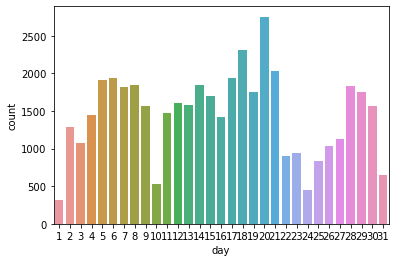

```python
# countplot for categrial columns
for i in ['education', 'month', 'poutcome', 'contact', 'loan','marital','job','housing','Target','day']:
     sns.countplot(bData[i])
     plt.show()
```

**Observation**

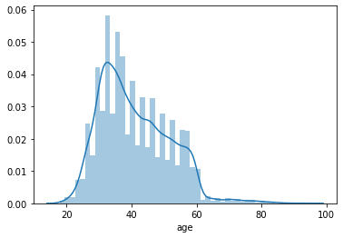

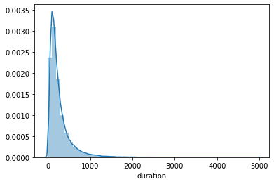

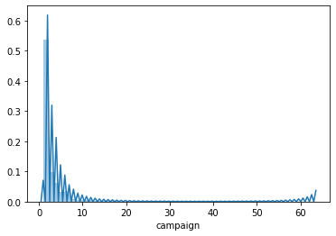

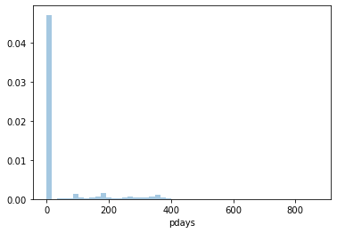

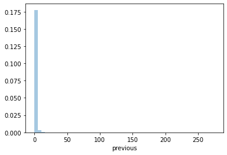

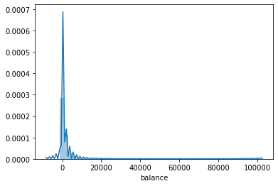

```python
# distplot for continous columns
for i in ['age', 'duration', 'campaign', 'pdays', 'previous','balance']:
     sns.distplot(bData[i])
     plt.show()
```

**Pre-Processing**

```python
bData['poutcome'].value_counts(normalize=True)
```

```
-1    0.817478
 1    0.108403
 2    0.040698
 3    0.033421
Name: poutcome, dtype: float64
```

```python
bData['previous'].value_counts(normalize=True)
```

```
0      0.817367
1      0.061313
2      0.046582
3      0.025259
4      0.015793
5      0.010152
6      0.006127
7      0.004534
8      0.002853
9      0.002035
10     0.001482
11     0.001438
12     0.000973
13     0.000841
15     0.000442
```

[output cut: 27 more lines]

```python
bData['pdays'].value_counts(normalize=True)
```

```
-1      0.817367
 182    0.003694
 92     0.003251
 183    0.002787
 91     0.002787
          ...
 749    0.000022
 717    0.000022
 589    0.000022
 493    0.000022
 32     0.000022
Name: pdays, Length: 559, dtype: float64
```

```python
bData['campaign'].value_counts(normalize=True)
```

```
1     0.388047
2     0.276592
3     0.122116
4     0.077901
5     0.039017
6     0.028555
7     0.016257
8     0.011944
9     0.007233
10    0.005884
11    0.004446
12    0.003428
13    0.002942
14    0.002057
15    0.001858
```

[output cut: 34 more lines]

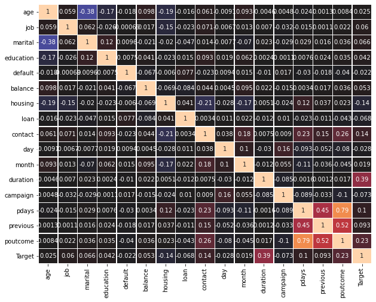

```python
plt.figure(figsize=(10,8))
sns.heatmap(bData.corr(),
            annot=True,
            linewidths=.5,
            center=0,
            cbar=False
           )

plt.show()
```

**Observation**

**PreProcessingTag1**

```python
#Dropping 'campaign', 'pdays','previous' and 'poutcome'- so we will delete this column
preBData = bData
for i in ['campaign', 'pdays','previous' , 'poutcome']:
     preBData.drop(i, axis=1, inplace=True)

preBData.head()
```

|  | age | job | marital | education | default | balance | housing | loan | contact | day | month | duration | Target |
| --- | --- | --- | --- | --- | --- | --- | --- | --- | --- | --- | --- | --- | --- |
| 0 | 58 | 2 | 1 | 3 | 1 | 2143 | 2 | 1 | -1 | 5 | 5 | 261 | 0 |
| 1 | 44 | 3 | 3 | 2 | 1 | 29 | 2 | 1 | -1 | 5 | 5 | 151 | 0 |
| 2 | 33 | 8 | 1 | 2 | 1 | 2 | 2 | 2 | -1 | 5 | 5 | 76 | 0 |
| 3 | 47 | 1 | 1 | -1 | 1 | 1506 | 2 | 1 | -1 | 5 | 5 | 92 | 0 |
| 4 | 33 | -1 | 3 | -1 | 1 | 1 | 1 | 1 | -1 | 5 | 5 | 198 | 0 |

```python
pd.crosstab(preBData['education'],preBData['Target'])
```

| Target education | 0 | 1 |
| --- | --- | --- |
| -1 | 1605 | 252 |
| 1 | 6260 | 591 |
| 2 | 20752 | 2450 |
| 3 | 11305 | 1996 |

**PreProcessingTag2**

**Think to consider:** `'education' is unknown values are very less as compared to huge dataset , but also significant rows(1800+) cannot be dropped . Imputing unknowns by merging unknown (-1) to second least categorical primary (1)`

```python
#Combine 7&8 together; combine 3 and 4 with 5 so that we have only 3 levels and a more balanced Y variable
preBData['education'] = preBData['education'].replace(-1,1)
preBData['education'].value_counts()
```

```
2    23202
3    13301
1     8708
Name: education, dtype: int64
```

```python
pd.crosstab(preBData['contact'],preBData['Target'],normalize='index')
```

| Target contact | 0 | 1 |
| --- | --- | --- |
| -1 | 0.959293 | 0.040707 |
| 1 | 0.850811 | 0.149189 |
| 2 | 0.865795 | 0.134205 |

```python
pd.crosstab(preBData['job'],preBData['Target'])
```

| Target job | 0 | 1 |
| --- | --- | --- |
| -1 | 254 | 34 |
| 1 | 9024 | 708 |
| 2 | 8157 | 1301 |
| 3 | 6757 | 840 |
| 4 | 4540 | 631 |
| 5 | 3785 | 369 |
| 6 | 1748 | 516 |
| 7 | 1392 | 187 |
| 8 | 1364 | 123 |
| 9 | 1101 | 202 |
| 10 | 1131 | 109 |
| 11 | 669 | 269 |

**PreProcessingTag3**

**Think to consider:**

- `'contact' is unknown values is second highest need to be imputed with median`
- `'job' is unknown values is least in all category , need to be imputed with median`

```python
#Use SimpleiImupter to replace -1 to median of Experience .
from sklearn.impute import SimpleImputer
rep_0 = SimpleImputer(missing_values=-1, strategy="median")
cols=['contact','job']
imputer = rep_0.fit(preBData[cols])
preBData[cols] = imputer.transform(preBData[cols])
```

```python
pd.crosstab(preBData['contact'],preBData['Target'],normalize='index')
```

| Target contact | 0 | 1 |
| --- | --- | --- |
| 1.0 | 0.884198 | 0.115802 |
| 2.0 | 0.865795 | 0.134205 |

```python
pd.crosstab(preBData['job'],preBData['Target'])
```

| Target job | 0 | 1 |
| --- | --- | --- |
| 1.0 | 9024 | 708 |
| 2.0 | 8157 | 1301 |
| 3.0 | 7011 | 874 |
| 4.0 | 4540 | 631 |
| 5.0 | 3785 | 369 |
| 6.0 | 1748 | 516 |
| 7.0 | 1392 | 187 |
| 8.0 | 1364 | 123 |
| 9.0 | 1101 | 202 |
| 10.0 | 1131 | 109 |
| 11.0 | 669 | 269 |

## Bivariate Analysis

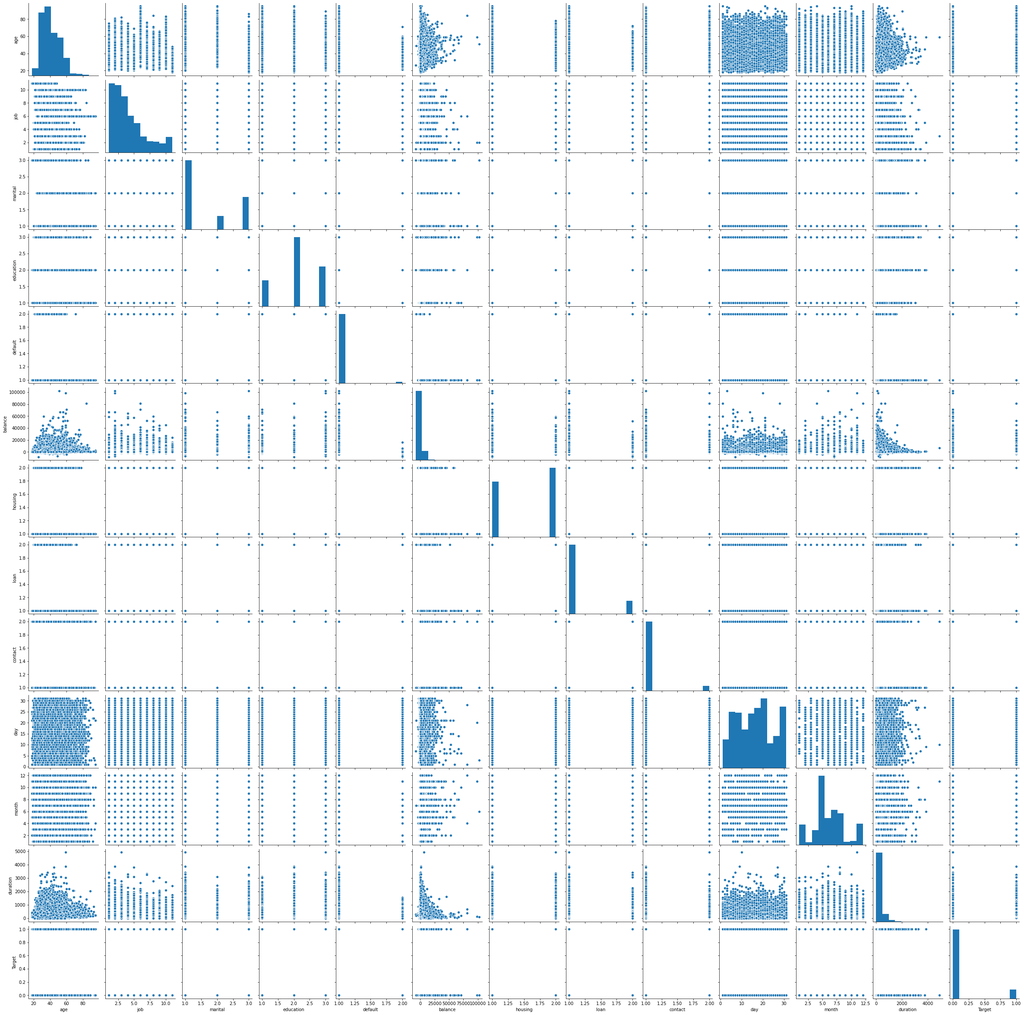

```python
sns.pairplot(preBData)
```

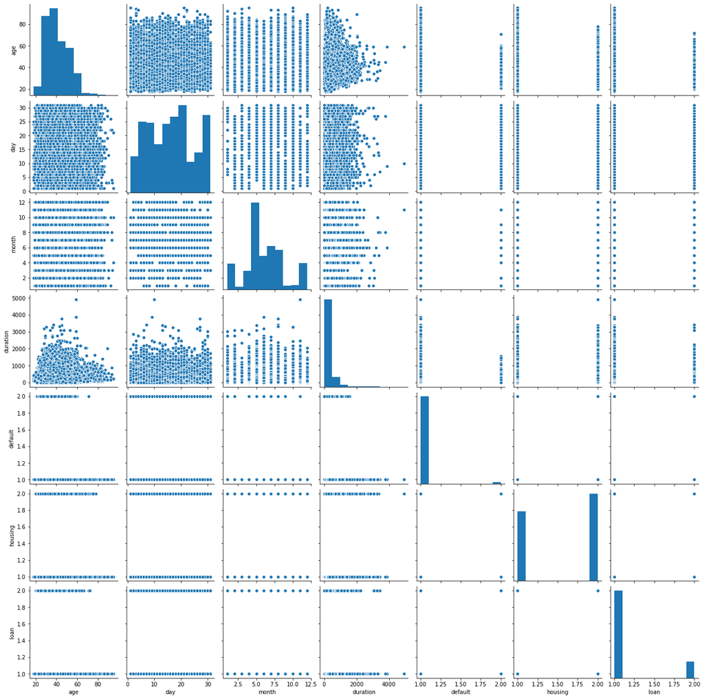

```python
sns.pairplot(preBData[['age', 'day', 'month', 'duration', 'default','housing','loan']])
```

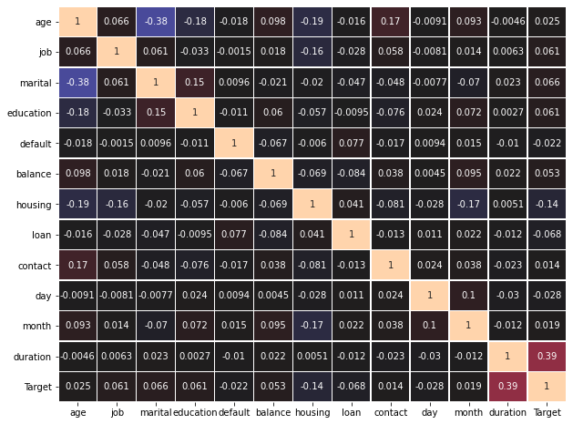

```python
plt.figure(figsize=(10,8))
sns.heatmap(preBData.corr(),
            annot=True,
            linewidths=.5,
            center=0,
            cbar=False
           )
plt.show()
```

**Observation**

- duration has maximum correlation with target, will be good candidate for decision tree/random forest models
- Correlation between columns is very less.

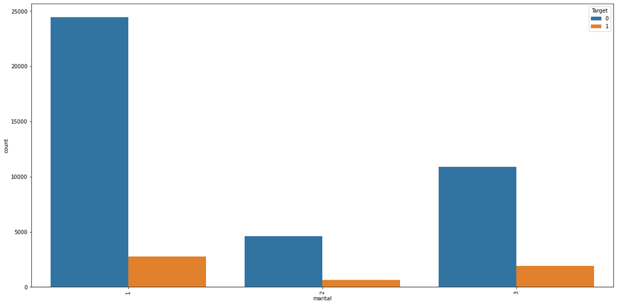

```python
#"marital": {"married": 1, "divorced":2 , "single": 3},
plt.figure(figsize=(20,10))
sns.countplot(x = 'marital',data=preBData,hue='Target')
plt.xticks(rotation=90)
plt.show()
```

**Observation**

- Across all marital category Target is not significatly different ("marital": {"married": 1, "divorced":2 , "single": 3},)

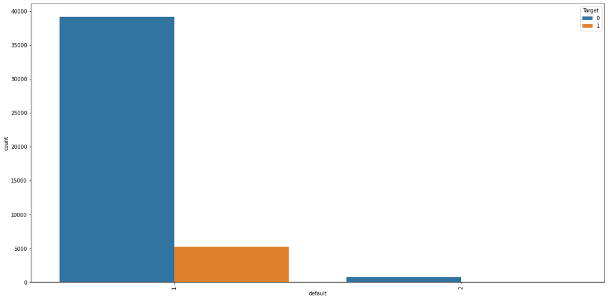

```python
plt.figure(figsize=(20,10))
sns.countplot(x = 'default',data=preBData,hue='Target')
plt.xticks(rotation=90)
plt.show()
```

**Observation**

- customer with 'no' default("default": {"no": 1, "yes": 2 }) category has an account. This could be a good candidate for conversion.

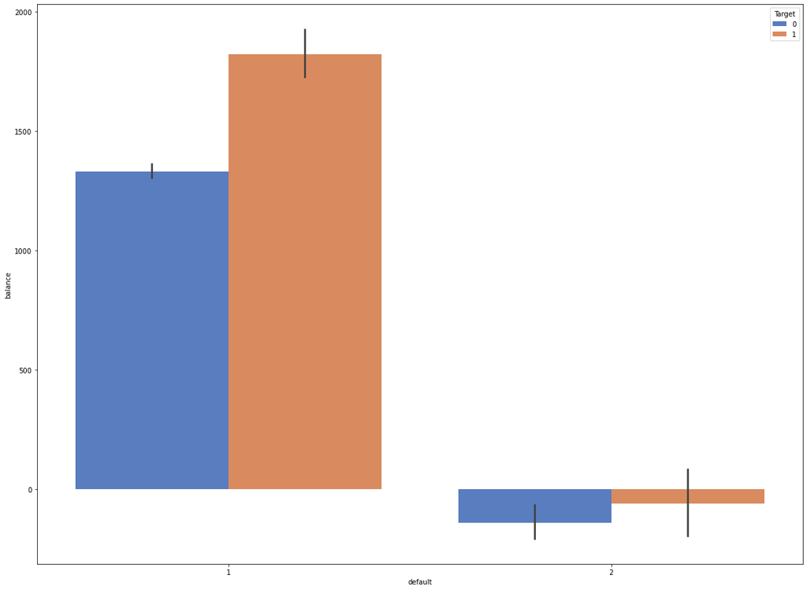

```python
plt.figure(figsize=(20,15))
sns.barplot(x="default", y="balance", hue="Target",data=preBData, palette="muted")
```

**Observation**

- Negative balance realized earlier Univariate analysis does make sense for customers who have defaulted.

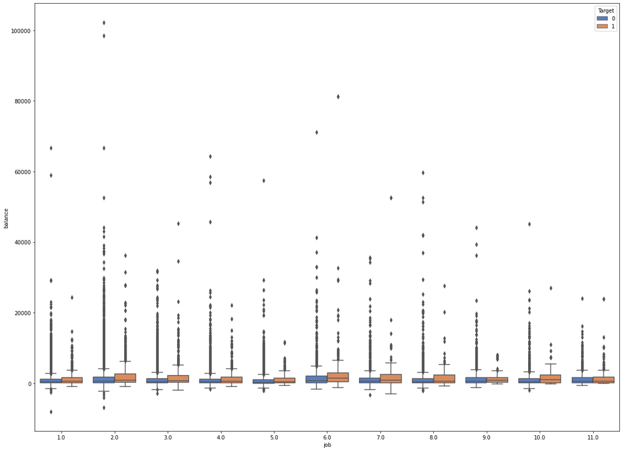

```python
plt.figure(figsize=(20,15))
sns.boxplot(x="job", y="balance", hue="Target",data=preBData, palette="muted")
```

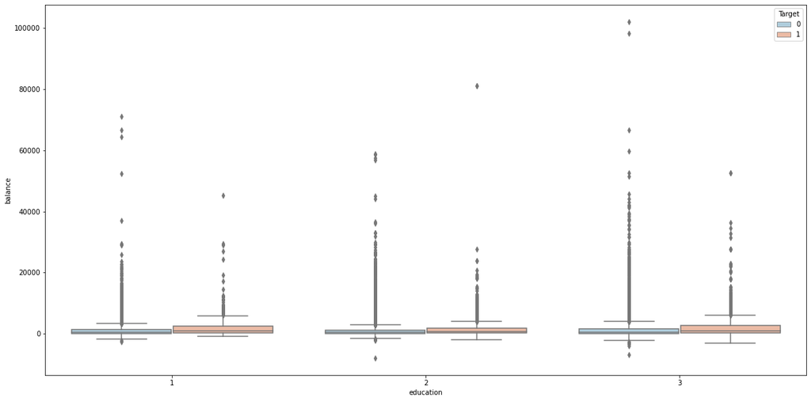

```python
plt.figure(figsize=(20,10))
sns.boxplot(data=preBData, x="education", y="balance", hue="Target", palette="RdBu_r")
```

**Observation**

"job": {"blue-collar": 1, "management": 2 ,"technician": 3 ,"admin.": 4, "services":5,"retired":6, "self-employed":7,"entrepreneur":8,"unemployed":9,"housemaid":10,"student":11,"unknown":-1}

"marital": {"married": 1, "divorced":2 , "single": 3}

"default": {"no": 1, "yes": 2 },

"education": {"primary": 1, "secondary":2 , "tertiary": 3,"unknown": -1}

## Prepare the data for analytics

**Data model is ready for further process**  
`As part of Univariate and Bivariate analysis we have already done pre processing cover above in "PreProcessingTag#":`

- `Converted all object columns to categorical set (PreProcessingTag0)`

- `Imputation:` `-- PreProcessingTag2: 'education' is unknown, values are very less as compared to huge dataset , but also significant rows(1800+) cannot be dropped . Imputing unknows by merging unknown (-1) to second least catagoric primary (1)'contact' is unknown values is second highest need to be imputed with median` `-- PreProcessingTag3: 'contact' is unknown values is second highest need to be imputed with median and 'job' is unknown values is least in all category , need to be imputed with medain`
- `Attribute types were correct in the initial stage by converting all object data types to Category.`

```python
## Define X and Y variables
X = preBData.drop('Target', axis=1)
Y = preBData[['Target']]
```

```python
X.head()
```

|  | age | job | marital | education | default | balance | housing | loan | contact | day | month | duration |
| --- | --- | --- | --- | --- | --- | --- | --- | --- | --- | --- | --- | --- |
| 0 | 58 | 2.0 | 1 | 3 | 1 | 2143 | 2 | 1 | 1.0 | 5 | 5 | 261 |
| 1 | 44 | 3.0 | 3 | 2 | 1 | 29 | 2 | 1 | 1.0 | 5 | 5 | 151 |
| 2 | 33 | 8.0 | 1 | 2 | 1 | 2 | 2 | 2 | 1.0 | 5 | 5 | 76 |
| 3 | 47 | 1.0 | 1 | 1 | 1 | 1506 | 2 | 1 | 1.0 | 5 | 5 | 92 |
| 4 | 33 | 3.0 | 3 | 1 | 1 | 1 | 1 | 1 | 1.0 | 5 | 5 | 198 |

```python
##Split into training and test set
from sklearn.model_selection import train_test_split

X_train, X_test, y_train, y_test = train_test_split(X, Y, test_size=0.30,random_state=7)
```

## Using Logistic Regression model to predict

Whether the customer will take Term Deposite or not. Print all the metrics related for evaluating the model performance

```python
import warnings
warnings.filterwarnings('ignore')
from sklearn.metrics import confusion_matrix, recall_score, precision_score, f1_score, roc_auc_score,accuracy_score
from sklearn.linear_model import LogisticRegression

logreg = LogisticRegression(random_state=7, solver="liblinear")
# fit the model on train data
logreg.fit(X_train, y_train)
```

```
LogisticRegression(random_state=7, solver='liblinear')
```

```python
# Predicting the target variable on test data
y_predict = logreg.predict(X_test)
```

```python
# Observe the predicted and observed classes in a dataframe.

z = X_test.copy()
z['Observed Personal Loan'] = y_test
z['Predicted Personal Loan'] = y_predict
z.tail()
```

|  | age | job | marital | education | default | balance | housing | loan | contact | day | month | duration | Observed Personal Loan | Predicted Personal Loan |
| --- | --- | --- | --- | --- | --- | --- | --- | --- | --- | --- | --- | --- | --- | --- |
| 34418 | 29 | 1.0 | 1 | 1 | 1 | 6 | 2 | 1 | 1.0 | 5 | 5 | 39 | 0 | 0 |
| 11563 | 48 | 5.0 | 2 | 1 | 1 | -110 | 1 | 2 | 1.0 | 19 | 6 | 164 | 0 | 0 |
| 43842 | 33 | 4.0 | 3 | 3 | 1 | 272 | 2 | 1 | 1.0 | 1 | 6 | 326 | 1 | 0 |
| 18061 | 40 | 3.0 | 1 | 2 | 1 | 657 | 2 | 1 | 1.0 | 30 | 7 | 159 | 0 | 0 |
| 33000 | 35 | 2.0 | 3 | 3 | 1 | 1045 | 2 | 1 | 1.0 | 17 | 4 | 204 | 0 | 0 |

```python
#Create function to plot ROC plot for given logistic regression (logreg) , dependent test data (y_data)
# and independent data (x_data)
#AUC ROC curve
from sklearn.metrics import roc_auc_score
from sklearn.metrics import roc_curve

def draw_roc(pLogreg,pX_data,pY_data):
    logit_roc_auc = roc_auc_score(pY_data, pLogreg.predict(pX_data))
    fpr, tpr, thresholds = roc_curve(pY_data, pLogreg.predict_proba(pX_data)[:,1])
    plt.figure()
    plt.plot(fpr, tpr, label='Logistic Regression (area = %0.2f)' % logit_roc_auc)
    plt.plot([0, 1], [0, 1],'r--')
    plt.xlim([0.0, 1.0])
    plt.ylim([0.0, 1.05])
    plt.xlabel('False Positive Rate')
    plt.ylabel('True Positive Rate')
    plt.title('Receiver operating characteristic')
    plt.legend(loc="lower right")
    plt.savefig('Log_ROC')
    plt.show()
```

```
Trainig accuracy 0.8867507188675072

Testing accuracy 0.8937629017988794

Recall: 0.19882659713168188

Precision: 0.5899419729206963

F1 Score: 0.29741589468551927

Roc Auc Score: 0.5906019934951843
```

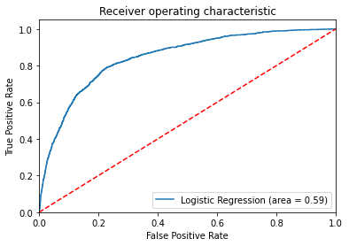

```python
print("Trainig accuracy",logreg.score(X_train,y_train))
print()
print("Testing accuracy",logreg.score(X_test, y_test))
print()
print("Recall:",recall_score(y_test,y_predict))
print()
print("Precision:",precision_score(y_test,y_predict))
print()
print("F1 Score:",f1_score(y_test,y_predict))
print()
print("Roc Auc Score:",roc_auc_score(y_test,y_predict))

draw_roc(logreg,X_test, y_test)
```

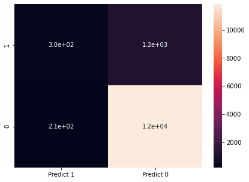

```python
from sklearn import metrics

cm=metrics.confusion_matrix(y_test, y_predict, labels=[1, 0])

df_cm = pd.DataFrame(cm, index = [i for i in ["1","0"]],
                  columns = [i for i in ["Predict 1","Predict 0"]])
plt.figure(figsize = (7,5))
sns.heatmap(df_cm, annot=True);
```

```python
#Store the accuracy results for each model in a dataframe for final comparison
resultsDf=None
resultsDf = pd.DataFrame({'Method':['Logistic Regression'], 'accuracy': logreg.score(X_test, y_test)})
resultsDf = resultsDf[['Method', 'accuracy']]
resultsDf
```

|  | Method | accuracy |
| --- | --- | --- |
| 0 | Logistic Regression | 0.893763 |

```python
from yellowbrick.classifier import ClassificationReport, ROCAUC
# Creating a function for visualizing classifier results
def visClassifierResults(model_w_parameters):
    viz = ClassificationReport(model_w_parameters)
    viz.fit(X_train, y_train)
    viz.score(X_test, y_test)
    viz.show()

    roc = ROCAUC(model_w_parameters)
    roc.fit(X_train, y_train)
    roc.score(X_test, y_test)
    roc.show()
```

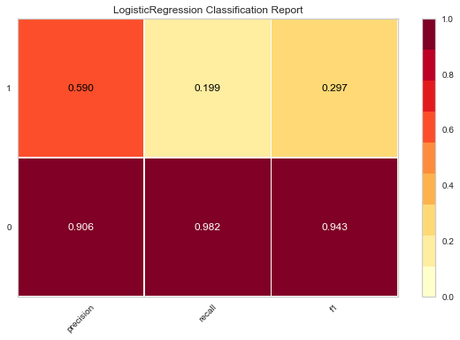

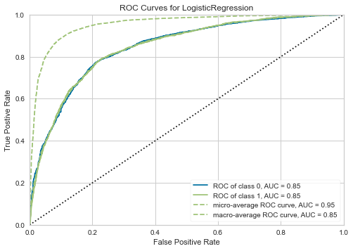

```python
# Visualize model performance with yellowbrick library
visClassifierResults(LogisticRegression(random_state=7, solver="liblinear"))
```

```python
from sklearn.tree import DecisionTreeClassifier
import warnings

warnings.filterwarnings('ignore')


model_gini = DecisionTreeClassifier(criterion='gini')
# fit the model on train data
model_gini.fit(X_train, y_train)
```

```
DecisionTreeClassifier()
```

```python
print("Train: %.2f" % model_gini.score(X_train, y_train))  # performance on train data
print("Test: %.2f" % model_gini.score(X_test, y_test))  # performance on test data
```

```
Train: 1.00
Test: 0.87
```

#### There is a high degree of overfitting in the model due to which the test accuracy drops drastically. This shows why decision trees are prone to overfitting.

#### Regularize/prune the decision tree by limiting the max. depth of trees and print the accuracy.

```python
clf_pruned = DecisionTreeClassifier(criterion = "gini", max_depth=5)
clf_pruned.fit(X_train, y_train)
```

```
DecisionTreeClassifier(max_depth=5)
```

```python
print("Train: %.2f" % clf_pruned.score(X_train, y_train))  # performance on train data
print("Test: %.2f" % clf_pruned.score(X_test, y_test))  # performance on test data
```

```
Train: 0.89
Test: 0.90
```

```python
preds_train = clf_pruned.predict(X_train)
preds_test = clf_pruned.predict(X_test)

acc_DT = accuracy_score(y_test, preds_test)
```

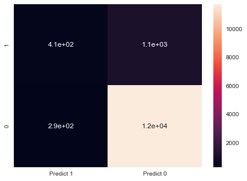

```python
# Confusion matrix
#pd.crosstab(y_test, preds_test, rownames=['Actual'], colnames=['Predicted'])

cm=metrics.confusion_matrix(y_test, preds_test, labels=[1, 0])

df_cm = pd.DataFrame(cm, index = [i for i in ["1","0"]],
                  columns = [i for i in ["Predict 1","Predict 0"]])
plt.figure(figsize = (7,5))
sns.heatmap(df_cm, annot=True);
```

```python
#pip install yellowbrick
```

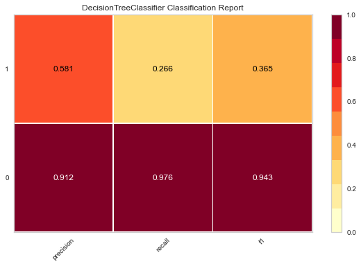

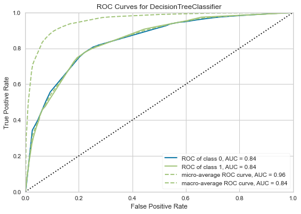

```python
# Visualize model performance with yellowbrick library
visClassifierResults(DecisionTreeClassifier(criterion = "gini", max_depth=5))
```

```python
df=preBData
features = [col for col in df.columns if col != 'Target']
```

```python
df['ProbQuality_5'] = clf_pruned.predict_proba(df[features])[:,0]
df['ProbQuality_6'] = clf_pruned.predict_proba(df[features])[:,1]

df.head(10)
```

|  | age | job | marital | education | default | balance | housing | loan | contact | day | month | duration | Target | ProbQuality_5 | ProbQuality_6 |
| --- | --- | --- | --- | --- | --- | --- | --- | --- | --- | --- | --- | --- | --- | --- | --- |
| 0 | 58 | 2.0 | 1 | 3 | 1 | 2143 | 2 | 1 | 1.0 | 5 | 5 | 261 | 0 | 0.934480 | 0.065520 |
| 1 | 44 | 3.0 | 3 | 2 | 1 | 29 | 2 | 1 | 1.0 | 5 | 5 | 151 | 0 | 0.992717 | 0.007283 |
| 2 | 33 | 8.0 | 1 | 2 | 1 | 2 | 2 | 2 | 1.0 | 5 | 5 | 76 | 0 | 0.992717 | 0.007283 |
| 3 | 47 | 1.0 | 1 | 1 | 1 | 1506 | 2 | 1 | 1.0 | 5 | 5 | 92 | 0 | 0.992717 | 0.007283 |
| 4 | 33 | 3.0 | 3 | 1 | 1 | 1 | 1 | 1 | 1.0 | 5 | 5 | 198 | 0 | 0.960402 | 0.039598 |
| 5 | 35 | 2.0 | 1 | 3 | 1 | 231 | 2 | 1 | 1.0 | 5 | 5 | 139 | 0 | 0.992717 | 0.007283 |
| 6 | 28 | 2.0 | 3 | 3 | 1 | 447 | 2 | 2 | 1.0 | 5 | 5 | 217 | 0 | 0.934480 | 0.065520 |
| 7 | 42 | 8.0 | 2 | 3 | 2 | 2 | 2 | 1 | 1.0 | 5 | 5 | 380 | 0 | 0.934480 | 0.065520 |
| 8 | 58 | 6.0 | 1 | 1 | 1 | 121 | 2 | 1 | 1.0 | 5 | 5 | 50 | 0 | 0.992717 | 0.007283 |
| 9 | 43 | 3.0 | 3 | 2 | 1 | 593 | 2 | 1 | 1.0 | 5 | 5 | 55 | 0 | 0.992717 | 0.007283 |

```python
## Calculating feature importance

feat_importance = clf_pruned.tree_.compute_feature_importances(normalize=False)


feat_imp_dict = dict(zip(features, clf_pruned.feature_importances_))
feat_imp = pd.DataFrame.from_dict(feat_imp_dict, orient='index')
feat_imp.sort_values(by=0, ascending=False)
```

|  | 0 |
| --- | --- |
| duration | 0.693756 |
| housing | 0.123500 |
| age | 0.056993 |
| month | 0.044395 |
| balance | 0.043132 |
| day | 0.026853 |
| marital | 0.007792 |
| job | 0.003579 |
| education | 0.000000 |
| default | 0.000000 |
| loan | 0.000000 |
| contact | 0.000000 |

```python
#Store the accuracy results for each model in a dataframe for final comparison
tempResultsDf = pd.DataFrame({'Method':['Decision Tree'], 'accuracy': [acc_DT]})
resultsDf = pd.concat([resultsDf, tempResultsDf])
resultsDf = resultsDf[['Method', 'accuracy']]
resultsDf
```

|  | Method | accuracy |
| --- | --- | --- |
| 0 | Logistic Regression | 0.893763 |
| 0 | Decision Tree | 0.895311 |